# Toxic Comment Classification

```python
from IPython.display import HTML

HTML('''<script>
code_show=true;
function code_toggle() {
 if (code_show){
 $('div.input').hide();
 } else {
 $('div.input').show();
 }
 code_show = !code_show
}
$( document ).ready(code_toggle);
</script>
<form action="javascript:code_toggle()"><input type="submit" value="Show/Hide Code"></form>''')
```

## Introduction

The background for the problem originates from the multitude of online forums, wherein people participate actively and make comments. Conversational toxicity on online platforms is a very big issue that can lead people to stop expressing themselves and/or to stop seeking others' opinions out of fear of abuse or harrassment. For an online forum, identifying toxicity of comments becomes very important to put a check on users from posting potentially hurtful comments, to craft more civil arguments when engaging in social discourse with others and to gauge the toxicity of users' comments.

[figure not shown]

## Objective

Given a group of sentences or paragraphs, used as a comment by a user in an online platform, classify it to belong to one or more of the following categories, such as **toxic, severe-toxic, obscene, threat, insult or identity-hate**. A model has to be created which predicts the probability of each type of toxicity for each comment.

## Dataset

A few details regarding the dataset are as follows:

1. The dataset comes from **Jigsaw's Toxic Comment Classification** challenge on **Kaggle**.
2. The dataset contains **159,571** labelled examples of **Wikipedia** comments that have been labelled by human raters for toxic behavior.
3. The types of toxicity are:
   1. Toxic
   2. Severe-toxic
   3. Obscene
   4. Threat
   5. Insult
   6. Identity-hate
4. The data comes in the schema of <id, comment_text, toxic, severe_toxic, obscene, threat, insult, identity_hate>, where the labels for _toxic, severe_toxic, obscene, threat, insult, and identity*hate* are all boolean.

[figure not shown]

**Note:** A comment can belong to one or more toxicity types. For example, second comment in the above image belong to three different toxicity types.

## Implementation Details

### Exploratory Data Analysis (EDA)

```python
%%capture

import pandas as pd
import numpy as np

#misc
import gc
import time
import warnings

#stats
# from scipy.misc import imread
from scipy import sparse
import scipy.stats as ss

#viz
import matplotlib.pyplot as plt
import matplotlib.gridspec as gridspec
import seaborn as sns
from wordcloud import WordCloud ,STOPWORDS
import PIL
from PIL import Image

#nlp
import string
import re    #for regex
import nltk, os
from nltk.corpus import stopwords
# import spacy
from nltk import pos_tag
from nltk.stem.wordnet import WordNetLemmatizer
from nltk.tokenize import word_tokenize
# Tweet tokenizer does not split at apostophes which is what we want
from nltk.tokenize import TweetTokenizer
from keras.preprocessing.text import Tokenizer



#FeatureEngineering
from sklearn.feature_extraction.text import TfidfVectorizer, CountVectorizer, HashingVectorizer
from sklearn.decomposition import TruncatedSVD
from sklearn.base import BaseEstimator, ClassifierMixin
from sklearn.utils.validation import check_X_y, check_is_fitted
from sklearn.linear_model import LogisticRegression
from sklearn import metrics
from sklearn.metrics import log_loss
from sklearn.model_selection import StratifiedKFold
from sklearn.model_selection import train_test_split


import keras
import tensorflow as tf
import pandas as pd
import numpy as np
import os, re
from gensim.models import KeyedVectors
from wordcloud import WordCloud, STOPWORDS
from tqdm import tqdm
import matplotlib.pyplot as plt
from collections import Counter
from operator import itemgetter
import nltk
from nltk.corpus import stopwords
from sklearn.model_selection import train_test_split
from sklearn import metrics
from keras.preprocessing.text import Tokenizer
from keras.preprocessing.sequence import pad_sequences
from keras.layers import Dense, Input, LSTM, Embedding, Dropout, Activation, CuDNNGRU, Conv1D, GRU, concatenate
from keras.layers import Bidirectional, GlobalMaxPool1D
from keras.models import Model
from keras import initializers, regularizers, constraints, optimizers, layers
from keras.layers import Bidirectional, GlobalMaxPool1D, Dropout, SpatialDropout1D, GlobalAveragePooling1D, GlobalMaxPooling1D
from keras.callbacks import LearningRateScheduler
import gc

#suppress warnings
import warnings
warnings.filterwarnings('ignore')
```

```python
%%capture

from nltk.stem import PorterStemmer
ps = PorterStemmer()
from nltk.stem.lancaster import LancasterStemmer
lc = LancasterStemmer()
from nltk.stem import SnowballStemmer
sb = SnowballStemmer("english")
nltk.download('stopwords')
nltk.download('wordnet')
stop_words = set(stopwords.words('english'))
color = sns.color_palette()
```

```python
train= pd.read_csv("Dataset/jigsaw-toxic-comment-classification-challenge/train.csv")
test= pd.read_csv("Dataset/jigsaw-toxic-comment-classification-challenge/test.csv")
```

The number and percentage of training and test samples as shown below:

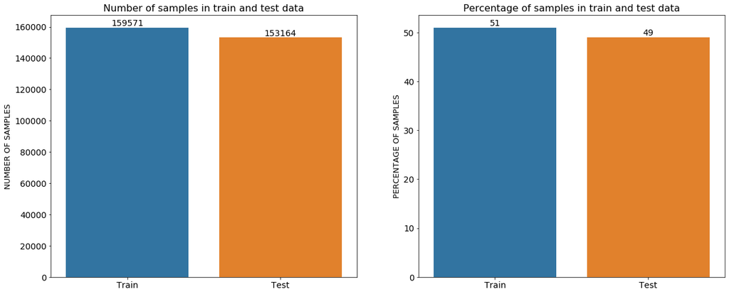

```python
nrow_train=train.shape[0]
nrow_test=test.shape[0]
sum=nrow_train+nrow_test
train_test_cnt_df= pd.DataFrame(columns= ['train_test', 'NUMBER OF SAMPLES', 'PERCENTAGE OF SAMPLES'])
train_test_cnt_df['train_test']= ['Train', 'Test']
train_test_cnt_df['NUMBER OF SAMPLES']= [nrow_train, nrow_test]
train_test_cnt_df['PERCENTAGE OF SAMPLES']= [round(nrow_train*100/sum), round(nrow_test*100/sum)]


f, axes = plt.subplots(1, 2, figsize=(20,8))
sns.barplot(x="train_test", y='NUMBER OF SAMPLES', data=train_test_cnt_df, ax= axes[0])
sns.barplot(x="train_test", y='PERCENTAGE OF SAMPLES', data=train_test_cnt_df, ax= axes[1])
axes[0].set_title('Number of samples in train and test data', fontsize=16)
axes[0].set_xlabel('',fontsize=13)
axes[0].set_ylabel('NUMBER OF SAMPLES', fontsize=13)
axes[0].tick_params(axis='both', which='major', labelsize=14)
axes[1].set_title('Percentage of samples in train and test data', fontsize=16)
axes[1].set_xlabel('',fontsize=13)
axes[1].set_ylabel('PERCENTAGE OF SAMPLES', fontsize=13)
axes[1].tick_params(axis='both', which='major', labelsize=14)
rects = axes[0].patches
labels = train_test_cnt_df['NUMBER OF SAMPLES']
for rect, label in zip(rects, labels):
    height = rect.get_height()
    axes[0].text(rect.get_x() + rect.get_width()/2, height + 5, label, ha='center', va='bottom', fontsize= 14)


rects = axes[1].patches
labels = train_test_cnt_df['PERCENTAGE OF SAMPLES']
for rect, label in zip(rects, labels):
    height = rect.get_height()
    axes[1].text(rect.get_x() + rect.get_width()/2, height, label, ha='center', va='bottom', fontsize= 14)

# print("       : train : test")
# print("rows   :",nrow_train,":",nrow_test)
# print("perc   :",round(nrow_train*100/sum),"   :",round(nrow_test*100/sum))
```

This is how the training data looks like:

```python
train.head()
```

|  | id | comment_text | toxic | severe_toxic | obscene | threat | insult | identity_hate | n_toxic_comments | n_chars | n_words | comment_text_clean | clean |
| --- | --- | --- | --- | --- | --- | --- | --- | --- | --- | --- | --- | --- | --- |
| 0 | 0000997932d777bf | Explanation\nWhy the edits made under my usern... | 0 | 0 | 0 | 0 | 0 | 0 | 0 | 264 | 43 | explanationwhy edit make username hardcore met... | True |
| 1 | 000103f0d9cfb60f | D'aww! He matches this background colour I'm s... | 0 | 0 | 0 | 0 | 0 | 0 | 0 | 112 | 17 | aww match background colour seemingly stick th... | True |
| 2 | 000113f07ec002fd | Hey man, I'm really not trying to edit war. It... | 0 | 0 | 0 | 0 | 0 | 0 | 0 | 233 | 42 | hey man really try edit war guy constantly rem... | True |
| 3 | 0001b41b1c6bb37e | "\nMore\nI can't make any real suggestions on ... | 0 | 0 | 0 | 0 | 0 | 0 | 0 | 622 | 113 | morei make real suggestions improvement wonder... | True |
| 4 | 0001d958c54c6e35 | You, sir, are my hero. Any chance you remember... | 0 | 0 | 0 | 0 | 0 | 0 | 0 | 67 | 13 | sir hero chance remember page | True |

```python
from IPython.display import display, HTML, Markdown
display(Markdown("__Number of missing values in Train dataset:__"))
null_check=pd.DataFrame(train.isnull().sum()).transpose()
display(HTML(null_check.to_html()))

display(Markdown("__Number of missing values in Test dataset:__"))
null_check=pd.DataFrame(test.isnull().sum()).transpose()
display(HTML(null_check.to_html()))
```

**Number of missing values in Train dataset:**

|  | id | comment_text | toxic | severe_toxic | obscene | threat | insult | identity_hate |
| --- | --- | --- | --- | --- | --- | --- | --- | --- |
| 0 | 0 | 0 | 0 | 0 | 0 | 0 | 0 | 0 |

**Number of missing values in Test dataset:**

|  | id | comment_text |
| --- | --- | --- |
| 0 | 0 | 0 |

As we can see above that there are **no missing values** in both training and test data.

The distribution of toxic and non-toxic comments, and different types of toxic comments are shown below.

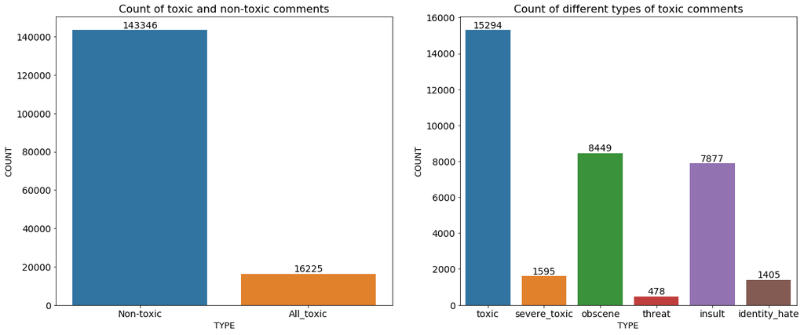

```python
train['n_toxic_comments']= np.sum(train.iloc[:,2:], axis=1)
label_cnt= np.sum(train.iloc[:,2:], axis=0)
label_cnt['Non-toxic']= np.sum(train['n_toxic_comments']==0)
label_cnt['All_toxic']= np.sum(train['n_toxic_comments']!=0)
label_cnt= pd.DataFrame(label_cnt, columns= ['a'])
label_cnt= label_cnt.reset_index()
label_cnt.columns= ['TYPE', 'COUNT']
label_cnt_1= label_cnt.iloc[0:6,:]
label_cnt_2= label_cnt.iloc[7:,:]
label_cnt_1,label_cnt_2

f, axes = plt.subplots(1, 2, figsize=(20,8))
sns.barplot(x="TYPE", y='COUNT', data=label_cnt_1, ax= axes[1])
sns.barplot(x="TYPE", y='COUNT', data=label_cnt_2, ax= axes[0])
axes[1].set_title('Count of different types of toxic comments', fontsize= 16)
axes[1].set_xlabel('TYPE', fontsize= 13)
axes[1].set_ylabel('COUNT', fontsize= 13)
axes[1].tick_params(axis='both', which='major', labelsize=14)
axes[0].set_title('Count of toxic and non-toxic comments', fontsize= 16)
axes[0].set_xlabel('TYPE', fontsize= 13)
axes[0].set_ylabel('COUNT', fontsize= 13)
axes[0].tick_params(axis='both', which='major', labelsize=14)
rects = axes[1].patches
labels = label_cnt_1.COUNT
for rect, label in zip(rects, labels):
    height = rect.get_height()
    axes[1].text(rect.get_x() + rect.get_width()/2, height + 5, label, ha='center', va='bottom', fontsize= 14)


rects = axes[0].patches
labels = label_cnt_2.COUNT
for rect, label in zip(rects, labels):
    height = rect.get_height()
    axes[0].text(rect.get_x() + rect.get_width()/2, height + 5, label, ha='center', va='bottom', fontsize= 14)
```

As we can see in the plots above:

1. The toxicity is not evenly spread out across classes. Hence we might face **class imbalance** problems
2. A single comment can be associated with multiple toxicity types, which makes it **multilabel classification** problem.

Let's check how many comments have multiple tags.

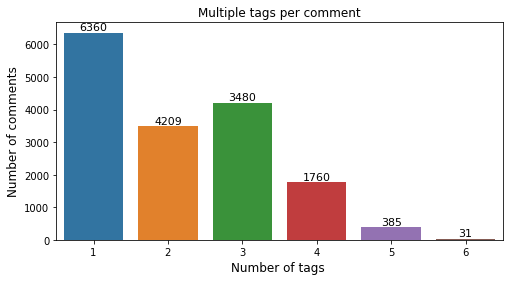

```python
plt.figure(figsize=(8,4))
ax= sns.countplot(x= 'n_toxic_comments', data= train[train['n_toxic_comments']!=0])
plt.title("Multiple tags per comment")
plt.ylabel('Number of comments', fontsize=12)
plt.xlabel('Number of tags ', fontsize=12)

#adding the text labels
rects = ax.patches
labels = train[train['n_toxic_comments']!=0]['n_toxic_comments'].value_counts().values
for rect, label in zip(rects, labels):
    height = rect.get_height()
    ax.text(rect.get_x() + rect.get_width()/2, height + 5, label, ha='center', va='bottom', fontsize= 11)

plt.show()
```

```python
train_labels=train.iloc[:,2:-1]
# # filter temp by removing clean comments
# # temp_df=temp_df[~train.clean]

# corr=train_labels.corr()
# plt.figure(figsize=(10,8))
# # ax= sns.heatmap(corr, xticklabels=corr.columns.values, yticklabels=corr.columns.values, annot=True)
# ax= sns.heatmap(corr, annot= True)
# ax.set_ylim(sorted(ax.get_xlim(), reverse=True))
# train_labels
```

The below table represents the Crosstab/ consufion matix of Toxic comments with the other classes.

```python
#Crosstab
# Since technically a crosstab between all 6 classes is impossible to vizualize, lets take a
# look at toxic with other tags
main_col="toxic"
corr_mats=[]
for other_col in train_labels.columns[1:]:
    confusion_matrix = pd.crosstab(train_labels[main_col], train_labels[other_col])
    corr_mats.append(confusion_matrix)

out = pd.concat(corr_mats,axis=1,keys=train_labels.columns[1:])

#cell highlighting
# out = out.style.apply(highlight_min,axis=0)
# out
out.columns.names= [None, None]
# display(HTML(out.to_html()))
out
```

| toxic | severe_toxic 0 | severe_toxic 1 | obscene 0 | obscene 1 | threat 0 | threat 1 | insult 0 | insult 1 | identity_hate 0 | identity_hate 1 |
| --- | --- | --- | --- | --- | --- | --- | --- | --- | --- | --- |
| 0 | 144277 | 0 | 143754 | 523 | 144248 | 29 | 143744 | 533 | 144174 | 103 |
| 1 | 13699 | 1595 | 7368 | 7926 | 14845 | 449 | 7950 | 7344 | 13992 | 1302 |

As we can see from above tab that:

- A **severe_toxic** comment is always **toxic**.
- Other classes seem to be a subset of toxic barring a few exceptions

Let's plot the histogram of length of comments and number of words in the corpus of comments.

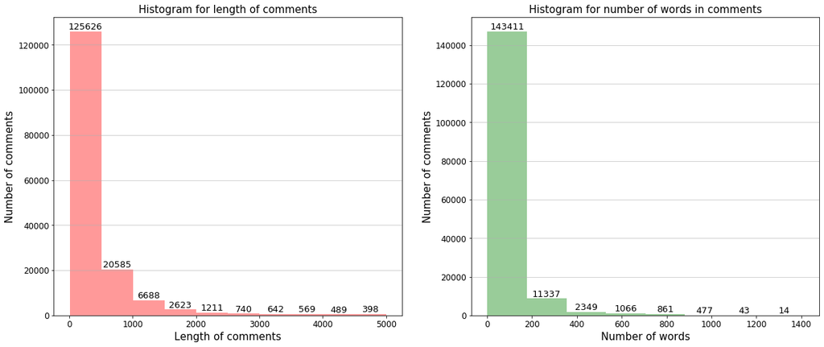

```python
train['n_chars']= train['comment_text'].apply(len)
train['n_words']= train['comment_text'].apply(lambda x: len(x.split()))

f, axes = plt.subplots(1, 2, figsize= (20,8))
sns.distplot(train["n_chars"], bins=10, kde= False, ax= axes[0], color='red')
sns.distplot(train["n_words"], bins=8, kde= False, ax= axes[1], color='green')
axes[0].set_title('Histogram for length of comments', fontsize=15)
axes[0].set_xlabel('Length of comments', fontsize=15)
axes[0].set_ylabel('Number of comments', fontsize=15)
axes[0].grid(axis='y', alpha= 0.7)
axes[0].tick_params(axis='both', which='major', labelsize=12)
axes[1].set_xlabel('Number of words', fontsize=15)
axes[1].set_ylabel('Number of comments', fontsize=15)
axes[1].set_title('Histogram for number of words in comments', fontsize=15)
axes[1].grid(axis='y', alpha= 0.7)
axes[1].tick_params(axis='both', which='major', labelsize=12)

rects = axes[0].patches
bins = np.arange(0, 5500, 500)
bin_range= pd.cut(train['n_chars'], bins= bins)
labels = bin_range.value_counts().values
for rect, label in zip(rects, labels):
    height = rect.get_height()
    axes[0].text(rect.get_x() + rect.get_width()/2, height + 5, label, ha='center', va='bottom', fontsize= 13)


rects = axes[1].patches
bins = np.arange(0, 1400, 150)
bin_range= pd.cut(train['n_words'], bins= bins)
labels = bin_range.value_counts().values
for rect, label in zip(rects, labels):
    height = rect.get_height()
    axes[1].text(rect.get_x() + rect.get_width()/2, height + 5, label, ha='center', va='bottom', fontsize= 13)
```

From above plots it can be seen that, majority of comments have smaller length and less number of words.

```python
# label = train[['toxic', 'severe_toxic' , 'obscene' , 'threat' , 'insult' , 'identity_hate']]
# comment = train['comment_text']
# label= label.as_matrix()
# comment= comment.as_matrix()
# y = np.zeros(label.shape)
# for ix in range(comment.shape[0]):
#     l = len(comment[ix])
#     if label[ix][0] :
#         y[ix][0] = l
#     if label[ix][1] :
#         y[ix][1] = l
#     if label[ix][2] :
#         y[ix][2] = l
#     if label[ix][3] :
#         y[ix][3] = l
#     if label[ix][4] :
#         y[ix][4] = l
#     if label[ix][5] :
#         y[ix][5] = l

# labelsplt = ['toxic','severe_toxic','obscene','threat','insult','identity_hate']
# color = ['red','green','blue','yellow','orange','chartreuse']
# plt.figure(figsize= (20,8))
# plt.hist(y,bins = bins,label = labelsplt,color = color)
# plt.axis([0, 1200, 0, 8000])
# plt.xlabel('Length of comments')
# plt.ylabel('Number of comments')
# plt.legend()
# plt.grid(True)
# plt.show()
```

#### Wordclouds

Now, let's make word clouds to identify which words are associated with these classes. In a word cloud, words with higher frequency appear bigger and words with lower frequency appear smaller.

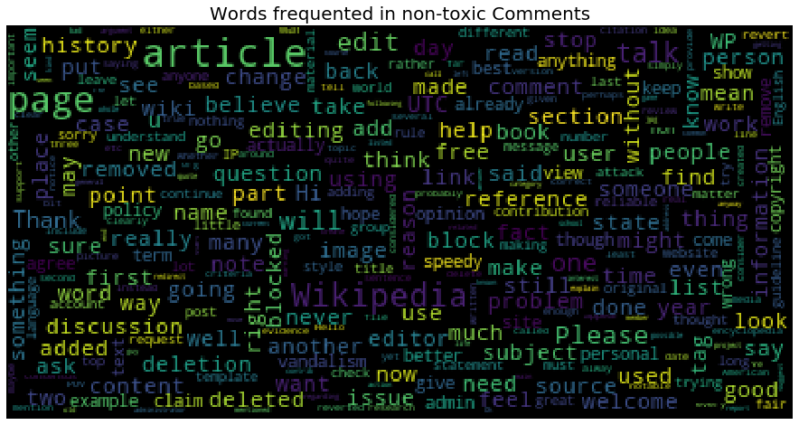

```python
def make_wordcloud(text, axes, fontsize):
    stopwords = set(STOPWORDS)
    wordcloud = WordCloud(
                          background_color='black',
                          stopwords=stopwords,
                          max_words=2000,
                          collocations = False,
                          max_font_size=fontsize,
                          random_state=42
                         ).generate(text)

    axes.imshow(wordcloud)
    plt.axis('off')

fig, axes = plt.subplots(1,1, figsize= (20,8))
make_wordcloud(train.loc[train['n_toxic_comments']==0,'comment_text'].str.cat(sep= ' '), axes, fontsize= 20)
axes.set_title("Words frequented in non-toxic Comments", fontsize=20)
plt.show()
```

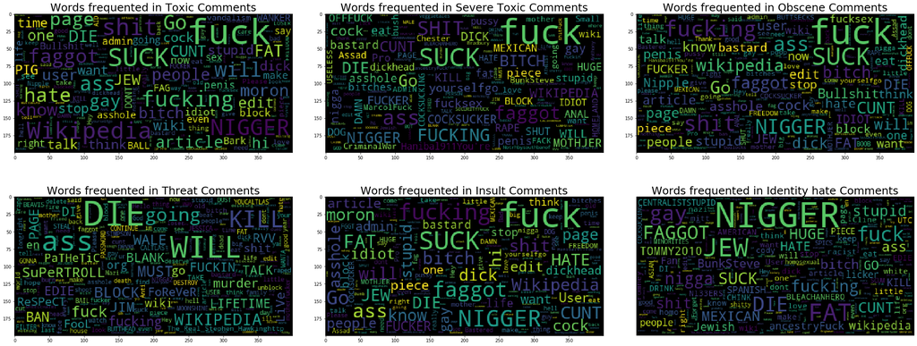

```python
f, axes = plt.subplots(2, 3, figsize= (30,12))
make_wordcloud(train.loc[train['toxic']==1,'comment_text'].str.cat(sep= ' '), axes[0][0], fontsize= 50)
axes[0][0].set_title("Words frequented in Toxic Comments", fontsize=25)
make_wordcloud(train.loc[train['severe_toxic']==1,'comment_text'].str.cat(sep= ' '), axes[0][1], fontsize= 50)
axes[0][1].set_title("Words frequented in Severe Toxic Comments", fontsize=25)
make_wordcloud(train.loc[train['obscene']==1,'comment_text'].str.cat(sep= ' '), axes[0][2], fontsize= 50)
axes[0][2].set_title("Words frequented in Obscene Comments", fontsize=25)
make_wordcloud(train.loc[train['threat']==1,'comment_text'].str.cat(sep= ' '), axes[1][0], fontsize= 50)
axes[1][0].set_title("Words frequented in Threat Comments", fontsize=25)
make_wordcloud(train.loc[train['insult']==1,'comment_text'].str.cat(sep= ' '), axes[1][1], fontsize= 50)
axes[1][1].set_title("Words frequented in Insult Comments", fontsize=25)
make_wordcloud(train.loc[train['identity_hate']==1,'comment_text'].str.cat(sep= ' '), axes[1][2], fontsize= 50)
axes[1][2].set_title("Words frequented in Identity hate Comments", fontsize=25)
plt.tight_layout()
plt.show()
```

#### Data Pre-processing

Comments can contain **URLs**, **IP addresses** (eg: 62.158.73.165), **usernames** (eg: ARKJEDI10) and some other numbers (eg: article-IDs), which can cause huge overfitting. That's why these need to be removed from the comments.

As part of data pre-processing, we do the following:

- Convert to lowercase
- Remove URLs, IPs, and usernames
- Remove stopwords
- Remove punctuations
- Replace contractions with its expansions
- Get the base form of words using lemmatization

```python
contraction_mapping = {"ain't": "is not", "aren't": "are not","can't": "cannot", "'cause": "because", "could've": "could have",
                       "couldn't": "could not", "didn't": "did not",  "doesn't": "does not", "don't": "do not", "hadn't": "had not",
                       "hasn't": "has not", "haven't": "have not", "he'd": "he would","he'll": "he will", "he's": "he is", "how'd": "how did",
                       "how'd'y": "how do you", "how'll": "how will", "how's": "how is",  "I'd": "I would", "I'd've": "I would have", "I'll": "I will",
                       "I'll've": "I will have","I'm": "I am", "I've": "I have", "i'd": "i would", "i'd've": "i would have", "i'll": "i will",
                       "i'll've": "i will have","i'm": "i am", "i've": "i have", "isn't": "is not", "it'd": "it would", "it'd've": "it would have",
                       "it'll": "it will", "it'll've": "it will have","it's": "it is", "let's": "let us", "ma'am": "madam", "mayn't": "may not",
                       "might've": "might have","mightn't": "might not","mightn't've": "might not have", "must've": "must have", "mustn't": "must not",
                       "mustn't've": "must not have", "needn't": "need not", "needn't've": "need not have","o'clock": "of the clock", "oughtn't": "ought not",
                       "oughtn't've": "ought not have", "shan't": "shall not", "sha'n't": "shall not", "shan't've": "shall not have",
                       "she'd": "she would", "she'd've": "she would have", "she'll": "she will", "she'll've": "she will have", "she's": "she is",
                       "should've": "should have", "shouldn't": "should not", "shouldn't've": "should not have", "so've": "so have","so's": "so as",
                       "this's": "this is","that'd": "that would", "that'd've": "that would have", "that's": "that is", "there'd": "there would",
                       "there'd've": "there would have", "there's": "there is", "here's": "here is","they'd": "they would", "they'd've": "they would have",
                       "they'll": "they will", "they'll've": "they will have", "they're": "they are", "they've": "they have", "to've": "to have",
                       "wasn't": "was not", "we'd": "we would", "we'd've": "we would have", "we'll": "we will", "we'll've": "we will have",
                       "we're": "we are", "we've": "we have", "weren't": "were not", "what'll": "what will", "what'll've": "what will have",
                       "what're": "what are",  "what's": "what is", "what've": "what have", "when's": "when is", "when've": "when have",
                       "where'd": "where did", "where's": "where is", "where've": "where have", "who'll": "who will", "who'll've": "who will have",
                       "who's": "who is", "who've": "who have", "why's": "why is", "why've": "why have", "will've": "will have", "won't": "will not",
                       "won't've": "will not have", "would've": "would have", "wouldn't": "would not", "wouldn't've": "would not have",
                       "y'all": "you all", "y'all'd": "you all would","y'all'd've": "you all would have","y'all're": "you all are", "y'all've": "you all have",
                       "you'd": "you would", "you'd've": "you would have", "you'll": "you will", "you'll've": "you will have", "you're": "you are",
                       "you've": "you have" }
```

```python
# this function contain the code for text cleaning.
tokenizer=TweetTokenizer()
lem = WordNetLemmatizer()
def do_cleaning(x, contraction_map):
    x = str(x)
    x= x.lower()
    x= re.sub(r'https?:\/\/[^ ]*', '', x) #to remove any urls
    x= re.sub(r'\d+.\d+.\d+.\d+', '', x)  #to remove any ip
    x= re.sub(r'\[\[.*\]', '', x)      #to remove any username enclosed in []

    for punct in "/-'":
        x = x.replace(punct, ' ')
    for punct in '&':
        x = x.replace(punct, f' {punct} ')
    for punct in '?!.,"#$%\'()*+-/:;<=>@[\\]^_`{|}~' + '“”’\n':
        x = x.replace(punct, '')
    x= re.sub(r' +', r' ', x)
    x= x.strip(' ')

    words=tokenizer.tokenize(x)

    # (')aphostophe  replacement (ie)   you're --> you are
    # ( basic dictionary lookup : master dictionary present in a hidden block of code)
    words=[contraction_map[word] if word in contraction_map else word for word in words]
    words=[lem.lemmatize(word, "v") for word in words]
    words = [w for w in words if not w in stop_words]

    clean_sent=" ".join(words)
    return clean_sent

train['comment_text_clean']= train['comment_text'].apply(lambda x: do_cleaning (x, contraction_mapping))
test['comment_text_clean']= test['comment_text'].apply(lambda x: do_cleaning (x, contraction_mapping))
```

```python
test.loc[test['comment_text_clean']=='', 'comment_text_clean']= '_na_'
train.loc[train['comment_text_clean']=='', 'comment_text_clean']= '_na_'
```

```python
#This function calculates the coverage/overlap of corpus vocabulary in different embeddings.
def calc_coverage(vocab, embedding, embed_type):
    vocab_words= set(vocab.keys())
    embed_words= set(embedding.keys())
    common_words= vocab_words.intersection(embed_words)
    total_words_match= 0
    for word in common_words:
        total_words_match+=vocab[word]
    oov_words= vocab_words - common_words
    oov_words_cnt= []
    for word in oov_words:
        oov_words_cnt.append((word,vocab[word]))
    oov_words_cnt.sort(key= itemgetter(1), reverse= True)
    total_corpus_len= np.sum(list(vocab.values()))
    pcntg_common_words= (len(common_words)/len(vocab_words))*100
    total_pcntg_words_match= (total_words_match/total_corpus_len)*100
    display(Markdown("_Total number of words in {} Embedding:_ __{}__".format(embed_type, len(embed_words))))
    display(Markdown("_Total number of common words between vocabulary and {} Embedding:_ __{}__".format(embed_type, len(common_words))))
    display(Markdown("_Percentage of common words between vocabulary and {} Embedding:_ __{}__".format(embed_type, pcntg_common_words)))
    display(Markdown("_Percentage of common words between our corpus and {} Embedding:_ __{}__".format(embed_type, total_pcntg_words_match)))
#     print("Total number of out of vocab words for {} Embedding: {}".format(embed_type, len(oov_words_cnt.keys())))
#     return oov_words_cnt
    return pcntg_common_words, total_pcntg_words_match


#  #This function calculates the coverage/overlap of corpus vocabulary in different embeddings.
# def calc_coverage(vocab, embedding_wiki, embedding_google, embedding_glove, embed_type):
#     vocab_words= set(vocab.keys())
#     embed_wiki_words= set(embedding_wiki.keys())
#     embed_google_words= set(embedding_google.keys())
#     embed_glove_words= set(embedding_glove.keys())
#     embed_combined_words= embed_wiki_words.union(embed_google_words).union(embed_glove_words)
#     common_words= vocab_words.intersection(embed_combined_words)
#     total_words_match= 0
#     for word in common_words:
#         total_words_match+=vocab[word]
#     oov_words= vocab_words - common_words
#     oov_words_cnt= []
#     for word in oov_words:
#         oov_words_cnt.append((word,vocab[word]))
#     oov_words_cnt.sort(key= itemgetter(1), reverse= True)
#     total_corpus_len= np.sum(list(vocab.values()))
#     pcntg_common_words= (len(common_words)/len(vocab_words))*100
#     total_pcntg_words_match= (total_words_match/total_corpus_len)*100
#     print("Total number of words in vocabulary:", len(vocab_words))
#     print("Total number of words in {} Embedding: {}".format(embed_type, len(embed_words)))
#     print("Total number of common words between vocabulary and {} Embedding: {}".format(embed_type, len(common_words)))
#     print("Percentage of common words between vocabulary and {} Embedding: {}".format(embed_type, pcntg_common_words))
#     print("Percentage of common words between our corpus and {} Embedding: {}".format(embed_type, total_pcntg_words_match))
# #     print("Total number of out of vocab words for {} Embedding: {}".format(embed_type, len(oov_words_cnt.keys())))
# #     return oov_words_cnt
#     return pcntg_common_words, total_pcntg_words_match
```

```python
#here we load differnt embeddings
glove= f'Dataset/Embeddings/glove.840B.300d.txt'
wiki= f'Dataset/Embeddings/wiki-news-300d-1M.vec'
google= f'Dataset/Embeddings/GoogleNews-vectors-negative300.bin'
# paragram= f'{path}data/paragram_300_sl999'
google_dict= {}
glove_dict= {}
wiki_dict= {}

def get_coefs(word,*arr): return word, np.asarray(arr, dtype='float32')
glove_dict = dict(get_coefs(*o.split(" ")) for o in open(glove))
wiki_dict = dict(get_coefs(*o.split(" ")) for o in open(wiki))
google_wv= KeyedVectors.load_word2vec_format(google, binary=True)
google_vocab= google_wv.wv.vocab
for word in google_vocab:
    google_dict[word]= google_wv.wv[word]

#Below are couple of spuriouss words which need to be removed.
del wiki_dict['999994']
del wiki_dict['saddler']

# glove_dict= glove_dict_tmp
# wiki_dict= wiki_dict_tmp
# google_dict= google_dict_tmp
```

```python
#this function finds count of each words in vocab
def make_vocab_cnt(sentences):
#     return Counter(texts.split(' '))
    vocab= {}
    for sentence in sentences:
        for word in sentence:
            if word in vocab:
                vocab[word]+=1
            else:
                vocab[word]= 1
    return vocab
#     retutn vocab_cnt

# vocab_cnt= make_vocab_cnt(train['question_text'].str.cat(sep=' '))
vocab_cnt= make_vocab_cnt(train['comment_text_clean'].apply(lambda x: x.split()).values)
```

Let's find out count of unique words in different embeddings and in our vocabulary.

*No of unique words in Glove embedding:* **2196016**

*No of unique words in Google embedding:* **3000000**

*No of unique words in Wiki embedding:* **999993**

*No of unique words in our vocabulary:* **240503**

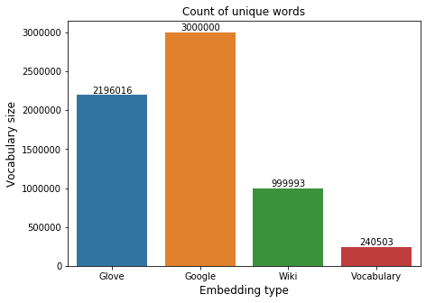

```python
display(Markdown("_No of unique words in Glove embedding:_ __{}__".format(len(glove_dict))))
display(Markdown("_No of unique words in Google embedding:_ __{}__".format(len(google_dict))))
display(Markdown("_No of unique words in Wiki embedding:_ __{}__".format(len(wiki_dict))))
display(Markdown("_No of unique words in our vocabulary:_ __{}__".format( len(list(vocab_cnt.keys())))))
embed_vocab_size= pd.DataFrame({'Embedding': ['Glove', 'Google', "Wiki", "Vocabulary" ], 'Vocab_size': [len(glove_dict), len(google_dict), len(wiki_dict), len(list(vocab_cnt.keys()))]})
plt.figure(figsize= (7,5))
ax= sns.barplot(x="Embedding", y='Vocab_size', data=embed_vocab_size)
ax.set_title('Count of unique words', fontsize=12)
ax.set_xlabel('Embedding type', fontsize=12)
ax.set_ylabel('Vocabulary size',  fontsize=12)
rects = ax.patches
labels = embed_vocab_size.Vocab_size
for rect, label in zip(rects, labels):
    height = rect.get_height()
    ax.text(rect.get_x() + rect.get_width()/2, height + 5, label, ha='center', va='bottom')
```

Let's find out the overlap between the vocabualry and these embeddings.  
The overlap between the vocabulary and these embeddings before pre-processing are given below:

```python
display(Markdown("_Total number of words in vocabulary:_ __{}__".format(len(list(vocab_cnt.keys())))))
print()
pcntg_common_words_df= pd.DataFrame(columns= ['Before', 'After', 'Embedding_type'])
total_pcntg_words_match_df= pd.DataFrame(columns= ['Before', 'After', 'Embedding_type'])
pcntg_common_words_1, total_pcntg_words_match_1= calc_coverage(vocab_cnt, google_dict, "Glove")
print()
pcntg_common_words_2, total_pcntg_words_match_2= calc_coverage(vocab_cnt, glove_dict, "Google")
print()
pcntg_common_words_3, total_pcntg_words_match_3= calc_coverage(vocab_cnt, wiki_dict, "Wiki")
pcntg_common_words_df['Before']= [pcntg_common_words_1,pcntg_common_words_2, pcntg_common_words_3]
total_pcntg_words_match_df['Before']= [total_pcntg_words_match_1, total_pcntg_words_match_2, total_pcntg_words_match_3]
pcntg_common_words_df['Embedding_type'] =  ['Glove', 'Google', "Wiki"]
total_pcntg_words_match_df['Embedding_type'] =  ['Glove', 'Google', "Wiki"]
```

*Total number of words in vocabulary:* **240503**

*Total number of common words between vocabulary and Glove Embedding:* **54520**

*Percentage of common words between vocabulary and Glove Embedding:* **22.669155894105273**

*Percentage of common words between our corpus and Glove Embedding:* **90.66276386827784**

*Total number of common words between vocabulary and Google Embedding:* **93787**

*Percentage of common words between vocabulary and Google Embedding:* **38.99618715774855**

*Percentage of common words between our corpus and Google Embedding:* **95.05695619893366**

*Total number of words in Wiki Embedding:* **999993**

*Total number of common words between vocabulary and Wiki Embedding:* **76413**

*Percentage of common words between vocabulary and Wiki Embedding:* **31.77216084622645**

*Percentage of common words between our corpus and Wiki Embedding:* **94.48176901819055**

```python
def load_embedding(word_dict, embeddings_index):
    embed_size = 300
    nb_words = len(word_dict)+1
#     embedding_matrix = np.zeros((nb_words, embed_size), dtype=np.float32)
    embedding_matrix= {}
    unknown_vector = np.zeros((embed_size,), dtype=np.float32) - 1.
#     print(unknown_vector[:5])
    for key in word_dict:
#         word = key
#         embedding_vector = embeddings_index.get(word)
#         if embedding_vector is not None:
#             embeddings_index[key] = embedding_vector
#             continue
        word = key.lower()
        embedding_vector = embeddings_index.get(word)
        if embedding_vector is not None:
            embeddings_index[key] = embedding_vector
            continue
        word = key.upper()
        embedding_vector = embeddings_index.get(word)
        if embedding_vector is not None:
            embeddings_index[key] = embedding_vector
            continue
        word = key.capitalize()
        embedding_vector = embeddings_index.get(word)
        if embedding_vector is not None:
            embeddings_index[key] = embedding_vector
            continue
#         word = ps.stem(key)
#         embedding_vector = embeddings_index.get(word)
#         if embedding_vector is not None:
#             embedding_matrix[key] = embedding_vector
#             continue
        word = lc.stem(key)
        embedding_vector = embeddings_index.get(word)
        if embedding_vector is not None:
            embeddings_index[key] = embedding_vector
            continue
        word = sb.stem(key)
        embedding_vector = embeddings_index.get(word)
        if embedding_vector is not None:
            embeddings_index[key] = embedding_vector
            continue
        word = lem.lemmatize(key, "v")
        embedding_vector = embeddings_index.get(word)
        if embedding_vector is not None:
            embeddings_index[key] = embedding_vector
            continue
#         embedding_matrix[key] = unknown_vector
    return embeddings_index, nb_words

glove_dict, n_words_glove= load_embedding(vocab_cnt, glove_dict)
wiki_dict, n_words_wiki= load_embedding(vocab_cnt, wiki_dict)
google_dict, n_words_google= load_embedding(vocab_cnt, google_dict)
# print(len(glove_dict), len(wiki_dict), len(google_dict))
```

The overlap between the vocabulary and these embeddings after pre-processing are given below:

```python
display(Markdown("_Total number of words in vocabulary:_ __{}__".format(len(list(vocab_cnt.keys())))))
print()
pcntg_common_words_1, total_pcntg_words_match_1= calc_coverage(vocab_cnt, google_dict, "Glove")
print()
pcntg_common_words_2, total_pcntg_words_match_2= calc_coverage(vocab_cnt, glove_dict, "Google")
print()
pcntg_common_words_3, total_pcntg_words_match_3= calc_coverage(vocab_cnt, wiki_dict, "Wiki")
pcntg_common_words_df['After']= [pcntg_common_words_1,pcntg_common_words_2, pcntg_common_words_3]
total_pcntg_words_match_df['After']= [total_pcntg_words_match_1, total_pcntg_words_match_2, total_pcntg_words_match_3]
pcntg_common_words_df['Embedding_type'] =  ['Glove', 'Google', "Wiki"]
total_pcntg_words_match_df['Embedding_type'] =  ['Glove', 'Google', "Wiki"]
```

*Total number of words in vocabulary:* **240503**

*Total number of common words between vocabulary and Glove Embedding:* **104166**

*Percentage of common words between vocabulary and Glove Embedding:* **43.3117258412577**

*Percentage of common words between our corpus and Glove Embedding:* **93.63966241581524**

*Total number of common words between vocabulary and Google Embedding:* **124798**

*Percentage of common words between vocabulary and Google Embedding:* **51.89041300940113**

*Percentage of common words between our corpus and Google Embedding:* **96.28795527473017**

*Total number of words in Wiki Embedding:* **1046952**

*Total number of common words between vocabulary and Wiki Embedding:* **123372**

*Percentage of common words between vocabulary and Wiki Embedding:* **51.29748901261107**

*Percentage of common words between our corpus and Wiki Embedding:* **96.42990275416278**

let's plot coverage of vocabulary and corpus with different embeddings before and after pre-processing.

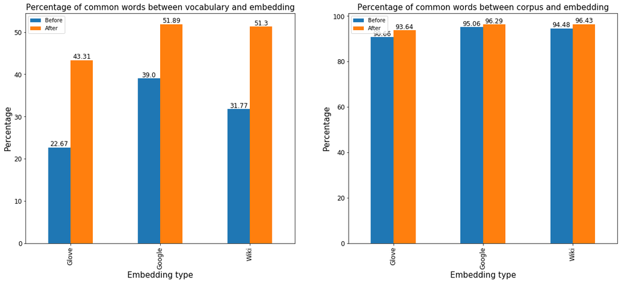

```python
pcntg_common_words_df= pcntg_common_words_df.round(2)
total_pcntg_words_match_df= total_pcntg_words_match_df.round(2)
fig, axes= plt.subplots(1,2, figsize= (20,8))
# plt.subplots(121)
pcntg_common_words_df.plot(x= 'Embedding_type', y= ['Before', 'After'], kind= 'bar', ax= axes[0])
axes[0].set_title("Percentage of common words between vocabulary and embedding", fontsize= 15)
axes[0].set_xlabel("Embedding type", fontsize= 15)
axes[0].set_ylabel("Percentage", fontsize= 15)
axes[0].tick_params(axis='both', which='major', labelsize=12)
total_pcntg_words_match_df.plot(x= 'Embedding_type', y= ['Before', 'After'], kind= 'bar', ax= axes[1])
axes[1].set_title("Percentage of common words between corpus and embedding", fontsize= 15)
axes[1].set_xlabel("Embedding type", fontsize= 15)
axes[1].set_ylabel("Percentage", fontsize= 15)
axes[1].tick_params(axis='both', which='major', labelsize=12)

rects = axes[0].patches
labels = pcntg_common_words_df.Before
for rect, label in zip(rects[:3], labels):
    height = rect.get_height()
    axes[0].text(rect.get_x() + rect.get_width()/2, height, label, ha='center', va='bottom', fontsize=12)

labels = pcntg_common_words_df.After
for rect, label in zip(rects[3:], labels):
    height = rect.get_height()
    axes[0].text(rect.get_x() + rect.get_width()/2, height, label, ha='center', va='bottom', fontsize=12)

rects = axes[1].patches
labels = total_pcntg_words_match_df.Before
for rect, label in zip(rects[:3], labels):
    height = rect.get_height()
    axes[1].text(rect.get_x() + rect.get_width()/2, height, label, ha='center', va='bottom', fontsize=12)

labels = total_pcntg_words_match_df.After
for rect, label in zip(rects[3:], labels):
    height = rect.get_height()
    axes[1].text(rect.get_x() + rect.get_width()/2, height, label, ha='center', va='bottom', fontsize=12)
```

#### Feature Engineering

The features we are interested in are as follows:

- count of sentences
- count of words
- count of unique words
- count of letters
- count of punctuations
- count of uppercase words
- count of stopwords
- Avg length of each word
- Percentage of unique words
- Percentage of punctuations
- count features (unigrams)
- bigrams

```python
rowsums=train.iloc[:,2:8].sum(axis=1)
train['clean']=(rowsums==0)
merge=pd.concat([train.iloc[:,0:2],test.iloc[:,0:2]])
df=merge.reset_index(drop=True)
```

```python
## Indirect features

#Sentense count in each comment:
    #  '\n' can be used to count the number of sentences in each comment
df['count_sent']=df["comment_text"].apply(lambda x: len(re.findall("\n",str(x)))+1)
#Word count in each comment:
df['count_word']=df["comment_text"].apply(lambda x: len(str(x).split()))
#Unique word count
df['count_unique_word']=df["comment_text"].apply(lambda x: len(set(str(x).split())))
#Letter count
df['count_letters']=df["comment_text"].apply(lambda x: len(str(x)))
#punctuation count
df["count_punctuations"] =df["comment_text"].apply(lambda x: len([c for c in str(x) if c in string.punctuation]))
#upper case words count
df["count_words_upper"] = df["comment_text"].apply(lambda x: len([w for w in str(x).split() if w.isupper()]))
#title case words count
df["count_words_title"] = df["comment_text"].apply(lambda x: len([w for w in str(x).split() if w.istitle()]))
#Number of stopwords
df["count_stopwords"] = df["comment_text"].apply(lambda x: len([w for w in str(x).lower().split() if w in stop_words]))
#Average length of the words
df["mean_word_len"] = df["comment_text"].apply(lambda x: np.mean([len(w) for w in str(x).split()]))
#derived features
#Word count percent in each comment:
df['word_unique_percent']=df['count_unique_word']*100/df['count_word']
#derived features
#Punct percent in each comment:
df['punct_percent']=df['count_punctuations']*100/df['count_word']
```

```python
#serperate train and test features
train_feats=df.iloc[0:len(train),]
test_feats=df.iloc[len(train):,]
#join the tags
train_tags=train.iloc[:,2:]
train_feats=pd.concat([train_feats,train_tags],axis=1)
test_feats.reset_index(drop=True, inplace= True)
test_feats=pd.concat([test_feats,test[['comment_text_clean']]],axis=1)
```

```python
train_tags= train_tags[['toxic', 'severe_toxic', 'obscene', 'threat', 'insult', 'identity_hate', 'clean',
       'n_toxic_comments', 'n_chars', 'n_words', 'comment_text_clean']]
```

Let's find out if toxicity depends on length of comments.

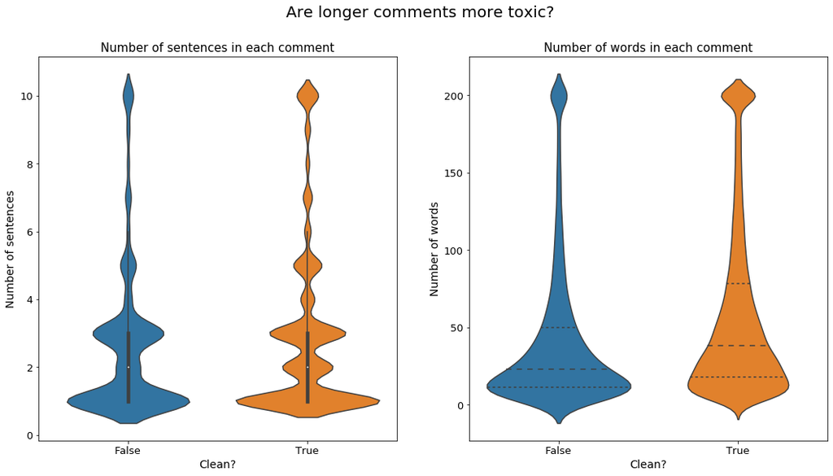

```python
train_feats['count_sent'].loc[train_feats['count_sent']>10] = 10
plt.figure(figsize=(18,9))
## sentenses
plt.subplot(121)
plt.suptitle("Are longer comments more toxic?",fontsize=20)
sns.violinplot(y='count_sent',x='clean', data=train_feats,split=True)
plt.xlabel('Clean?', fontsize=14)
plt.ylabel('Number of sentences', fontsize=14)
plt.title("Number of sentences in each comment", fontsize=15)
plt.tick_params(axis='both', which='major', labelsize=13)
# words
train_feats['count_word'].loc[train_feats['count_word']>200] = 200
plt.subplot(122)
sns.violinplot(y='count_word',x='clean', data=train_feats,split=True,inner="quart")
plt.xlabel('Clean?', fontsize=14)
plt.ylabel('Number of words', fontsize=14)
plt.title("Number of words in each comment", fontsize=15)
plt.tick_params(axis='both', which='major', labelsize=13)
plt.show()
```

From above plots it can be seen that, long sentences or more words do not seem to be a significant indicator of toxicity.

```python
train_feats['count_unique_word'].loc[train_feats['count_unique_word']>200] = 200
#prep for split violin plots
#For the desired plots , the data must be in long format
temp_df = pd.melt(train_feats, value_vars=['count_word', 'count_unique_word'], id_vars='clean')
#spammers - comments with less than 40% unique words
spammers=train_feats[train_feats['word_unique_percent']<30]
```

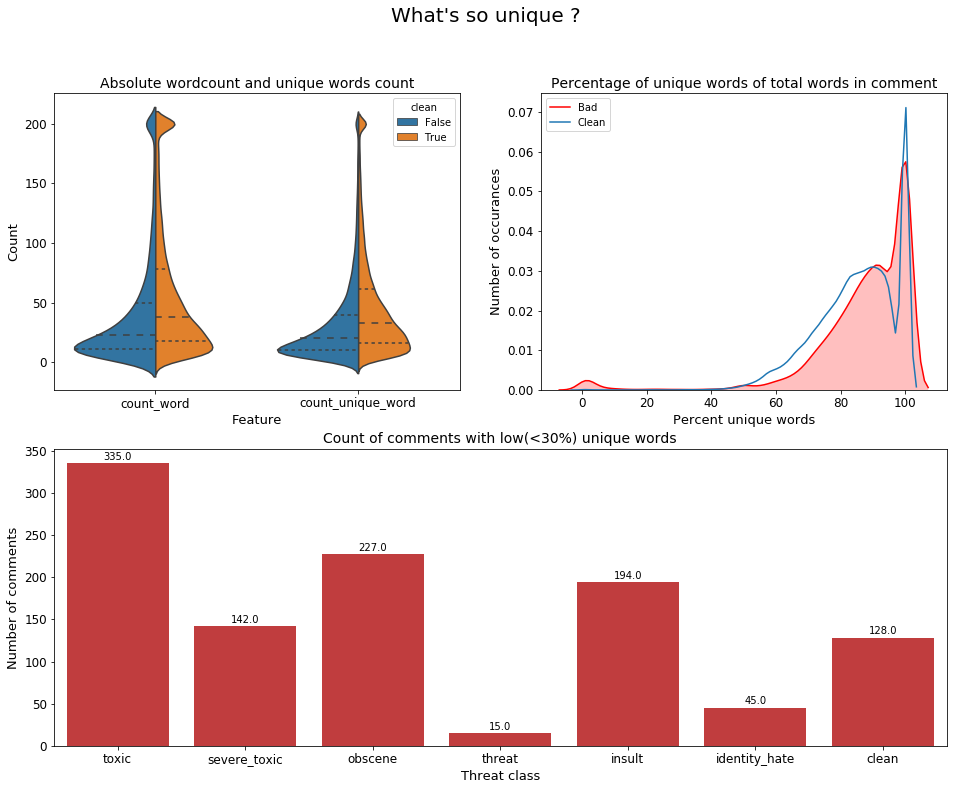

```python
plt.figure(figsize=(16,12))
plt.suptitle("What's so unique ?",fontsize=20)
gridspec.GridSpec(2,2)
plt.subplot2grid((2,2),(0,0))
sns.violinplot(x='variable', y='value', hue='clean', data=temp_df,split=True,inner='quartile')
plt.title("Absolute wordcount and unique words count", fontsize= 14)
plt.xlabel('Feature', fontsize=13)
plt.ylabel('Count', fontsize=13)
plt.tick_params(axis='both', which='major', labelsize=12)

plt.subplot2grid((2,2),(0,1))
plt.title("Percentage of unique words of total words in comment", fontsize= 14)
#sns.boxplot(x='clean', y='word_unique_percent', data=train_feats)
ax=sns.kdeplot(train_feats[train_feats.clean == 0].word_unique_percent, label="Bad",shade=True,color='r')
ax=sns.kdeplot(train_feats[train_feats.clean == 1].word_unique_percent, label="Clean")
plt.legend()
plt.ylabel('Number of occurances', fontsize=13)
plt.xlabel('Percent unique words', fontsize=13)
plt.tick_params(axis='both', which='major', labelsize=12)

x=spammers.iloc[:,[13,14,15,16,17,18,23]].sum()
plt.subplot2grid((2,2),(1,0),colspan=2)
plt.title("Count of comments with low(<30%) unique words",fontsize=14)
ax=sns.barplot(x=x.index, y=x.values,color=color[3])

#adding the text labels
rects = ax.patches
labels = x.values
for rect, label in zip(rects, labels):
    height = rect.get_height()
    ax.text(rect.get_x() + rect.get_width()/2, height + 2, label, ha='center', va='bottom')

plt.xlabel('Threat class', fontsize=13)
plt.ylabel('Number of comments', fontsize=13)
plt.tick_params(axis='both', which='major', labelsize=12)
plt.show()
```

From the above plots it can be seen that:

- In the first plot above it can be seen that, there are noticeable shifts in the mean of both word count and unique word count across clean and toxic comments.
- In the second plot above it can be seen that, there is a bulge near the 0-10% mark which indicates a large number of toxic comments which contain very little variety of words.
- In the third plot above it can be seen that, even though the number of clean comments dominates the dataset (~90%), there are only 128 clean comments that have less than 30\% unique words, which makes this feature a powerful indicator of a toxic comment.

```python
start_unigrams=time.time()
tfv = TfidfVectorizer(min_df=200,  max_features=10000,
            strip_accents='unicode', analyzer='word',ngram_range=(1,1),
            use_idf=1,smooth_idf=1,sublinear_tf=1,
            stop_words = 'english')
tfv.fit(train_feats['comment_text_clean'])
features = np.array(tfv.get_feature_names())

train_unigrams =  tfv.transform(train_feats['comment_text_clean'].iloc[:train.shape[0]])
# test_unigrams = tfv.transform(train['comment_text_clean'].iloc[train.shape[0]:])
```

```python
def top_tfidf_feats(row, features, top_n=25):
    ''' Get top n tfidf values in row and return them with their corresponding feature names.'''
    topn_ids = np.argsort(row)[::-1][:top_n]
    top_feats = [(features[i], row[i]) for i in topn_ids]
    df = pd.DataFrame(top_feats)
    df.columns = ['feature', 'tfidf']
    return df

def top_feats_in_doc(Xtr, features, row_id, top_n=25):
    ''' Top tfidf features in specific document (matrix row) '''
    row = np.squeeze(Xtr[row_id].toarray())
    return top_tfidf_feats(row, features, top_n)

def top_mean_feats(Xtr, features, grp_ids, min_tfidf=0.1, top_n=25):
    ''' Return the top n features that on average are most important amongst documents in rows
        indentified by indices in grp_ids. '''

    D = Xtr[grp_ids].toarray()

    D[D < min_tfidf] = 0
    tfidf_means = np.mean(D, axis=0)
    return top_tfidf_feats(tfidf_means, features, top_n)

# modified for multilabel milticlass
def top_feats_by_class(Xtr, features, min_tfidf=0.1, top_n=20):
    ''' Return a list of dfs, where each df holds top_n features and their mean tfidf value
        calculated across documents with the same class label. '''
    dfs = []
    cols=train_tags.columns
    for col in cols:
        ids = train_tags.index[train_tags[col]==1]
        feats_df = top_mean_feats(Xtr, features, ids, min_tfidf=min_tfidf, top_n=top_n)
        feats_df.label = label
        dfs.append(feats_df)
    return dfs
```

Let's plot the Tf-Idf score of top words (**unigrams**) for different types of toxic comments.

```python
#get top n for unigrams
tfidf_top_n_per_lass=top_feats_by_class(train_unigrams,features)

end_unigrams=time.time()
```

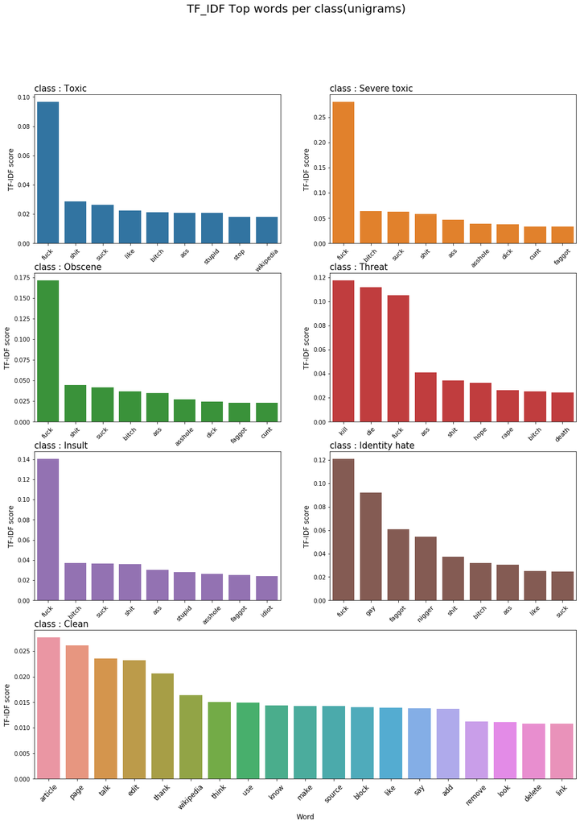

```python
plt.figure(figsize=(17,22))
plt.suptitle("TF_IDF Top words per class(unigrams)",fontsize=20)
gridspec.GridSpec(4,2)
plt.subplot2grid((4,2),(0,0))
sns.barplot(tfidf_top_n_per_lass[0].feature.iloc[0:9],tfidf_top_n_per_lass[0].tfidf.iloc[0:9],color=color[0])
plt.title("class : Toxic",fontsize=15, loc= 'left')
plt.xlabel('', fontsize=12)
plt.ylabel('TF-IDF score', fontsize=12)
plt.tick_params(axis='x', which='major', labelsize=11, labelrotation= 45)

plt.subplot2grid((4,2),(0,1))
sns.barplot(tfidf_top_n_per_lass[1].feature.iloc[0:9],tfidf_top_n_per_lass[1].tfidf.iloc[0:9],color=color[1])
plt.title("class : Severe toxic",fontsize=15, loc= 'left')
plt.xlabel('', fontsize=12)
plt.ylabel('TF-IDF score', fontsize=12)
plt.tick_params(axis='x', which='major', labelsize=11, labelrotation= 45)

plt.subplot2grid((4,2),(1,0))
sns.barplot(tfidf_top_n_per_lass[2].feature.iloc[0:9],tfidf_top_n_per_lass[2].tfidf.iloc[0:9],color=color[2])
plt.title("class : Obscene",fontsize=15, loc= 'left')
plt.xlabel('', fontsize=12)
plt.ylabel('TF-IDF score', fontsize=12)
plt.tick_params(axis='x', which='major', labelsize=11, labelrotation= 45)

plt.subplot2grid((4,2),(1,1))
sns.barplot(tfidf_top_n_per_lass[3].feature.iloc[0:9],tfidf_top_n_per_lass[3].tfidf.iloc[0:9],color=color[3])
plt.title("class : Threat",fontsize=15, loc= 'left')
plt.xlabel('', fontsize=12)
plt.ylabel('TF-IDF score', fontsize=12)
plt.tick_params(axis='x', which='major', labelsize=11, labelrotation= 45)

plt.subplot2grid((4,2),(2,0))
sns.barplot(tfidf_top_n_per_lass[4].feature.iloc[0:9],tfidf_top_n_per_lass[4].tfidf.iloc[0:9],color=color[4])
plt.title("class : Insult",fontsize=15, loc= 'left')
plt.xlabel('', fontsize=12)
plt.ylabel('TF-IDF score', fontsize=12)
plt.tick_params(axis='x', which='major', labelsize=11, labelrotation= 45)

plt.subplot2grid((4,2),(2,1))
sns.barplot(tfidf_top_n_per_lass[5].feature.iloc[0:9],tfidf_top_n_per_lass[5].tfidf.iloc[0:9],color=color[5])
plt.title("class : Identity hate",fontsize=15, loc= 'left')
plt.xlabel('', fontsize=12)
plt.ylabel('TF-IDF score', fontsize=12)
plt.tick_params(axis='x', which='major', labelsize=11, labelrotation= 45)

plt.subplot2grid((4,2),(3,0),colspan=2)
sns.barplot(tfidf_top_n_per_lass[6].feature.iloc[0:19],tfidf_top_n_per_lass[6].tfidf.iloc[0:19])
plt.title("class : Clean",fontsize=15, loc= 'left')
plt.xlabel('Word', fontsize=12)
plt.ylabel('TF-IDF score', fontsize=12)
plt.tick_params(axis='x', which='major', labelsize=12, labelrotation= 45)

plt.show()
```

```python
#temp settings to min=150 to facilitate top features section to run in kernels
#change back to min=10 to get better results
tfv = TfidfVectorizer(min_df=150,  max_features=30000,
            strip_accents='unicode', analyzer='word',ngram_range=(2,2),
            use_idf=1,smooth_idf=1,sublinear_tf=1,
            stop_words = 'english')


tfv.fit(train_feats['comment_text_clean'])
features = np.array(tfv.get_feature_names())

train_bigrams =  tfv.transform(train_feats['comment_text_clean'].iloc[:train.shape[0]])
#get top n for bigrams
tfidf_top_n_per_lass=top_feats_by_class(train_bigrams,features)
```

Let's plot the Tf-Idf score of top word pairs (**bigrams**) for different type of toxic comments.

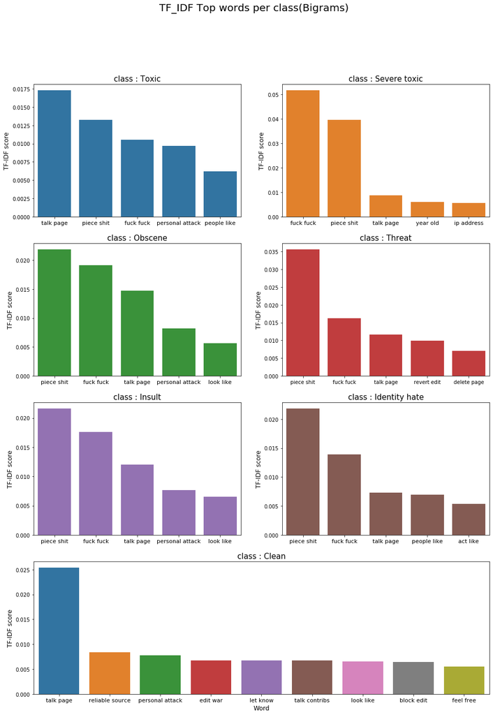

```python
plt.figure(figsize=(16,22))
plt.suptitle("TF_IDF Top words per class(Bigrams)",fontsize=20)
gridspec.GridSpec(4,2)
plt.subplot2grid((4,2),(0,0))
sns.barplot(tfidf_top_n_per_lass[0].feature.iloc[0:5],tfidf_top_n_per_lass[0].tfidf.iloc[0:5],color=color[0])
plt.title("class : Toxic",fontsize=15)
plt.xlabel('', fontsize=12)
plt.ylabel('TF-IDF score', fontsize=12)
plt.tick_params(axis='x', which='major', labelsize=11)


plt.subplot2grid((4,2),(0,1))
sns.barplot(tfidf_top_n_per_lass[1].feature.iloc[0:5],tfidf_top_n_per_lass[1].tfidf.iloc[0:5],color=color[1])
plt.title("class : Severe toxic",fontsize=15)
plt.xlabel('', fontsize=12)
plt.ylabel('TF-IDF score', fontsize=12)
plt.tick_params(axis='x', which='major', labelsize=11)


plt.subplot2grid((4,2),(1,0))
sns.barplot(tfidf_top_n_per_lass[2].feature.iloc[0:5],tfidf_top_n_per_lass[2].tfidf.iloc[0:5],color=color[2])
plt.title("class : Obscene",fontsize=15)
plt.xlabel('', fontsize=12)
plt.ylabel('TF-IDF score', fontsize=12)
plt.tick_params(axis='x', which='major', labelsize=11)


plt.subplot2grid((4,2),(1,1))
sns.barplot(tfidf_top_n_per_lass[3].feature.iloc[0:5],tfidf_top_n_per_lass[3].tfidf.iloc[0:5],color=color[3])
plt.title("class : Threat",fontsize=15)
plt.xlabel('', fontsize=12)
plt.ylabel('TF-IDF score', fontsize=12)


plt.subplot2grid((4,2),(2,0))
sns.barplot(tfidf_top_n_per_lass[4].feature.iloc[0:5],tfidf_top_n_per_lass[4].tfidf.iloc[0:5],color=color[4])
plt.title("class : Insult",fontsize=15)
plt.xlabel('', fontsize=12)
plt.ylabel('TF-IDF score', fontsize=12)
plt.tick_params(axis='x', which='major', labelsize=11)


plt.subplot2grid((4,2),(2,1))
sns.barplot(tfidf_top_n_per_lass[5].feature.iloc[0:5],tfidf_top_n_per_lass[5].tfidf.iloc[0:5],color=color[5])
plt.title("class : Identity hate",fontsize=15)
plt.xlabel('', fontsize=12)
plt.ylabel('TF-IDF score', fontsize=12)
plt.tick_params(axis='x', which='major', labelsize=11)


plt.subplot2grid((4,2),(3,0),colspan=2)
sns.barplot(tfidf_top_n_per_lass[6].feature.iloc[0:9],tfidf_top_n_per_lass[6].tfidf.iloc[0:9])
plt.title("class : Clean",fontsize=15)
plt.xlabel('Word', fontsize=12)
plt.ylabel('TF-IDF score', fontsize=12)
plt.tick_params(axis='x', which='major', labelsize=11)


plt.show()
```

#### Modelling

A few modelling details are as follows:

```python
vocab_size= 30000
embed_size= 300
NUM_MODELS = 2
BATCH_SIZE = 512
LSTM_UNITS = 128
DENSE_HIDDEN_UNITS = 4 * LSTM_UNITS
EPOCHS = 4
maxlen = 200
```

```python
SELECTED_COLS=['count_sent', 'count_word', 'count_unique_word',
       'count_letters', 'count_punctuations', 'count_words_upper',
       'count_words_title', 'count_stopwords', 'mean_word_len',
       'word_unique_percent', 'punct_percent']
# target_x=train_feats[SELECTED_COLS]
TARGET_COLS=['toxic', 'severe_toxic', 'obscene', 'threat', 'insult', 'identity_hate']
# target_y=train_feats[TARGET_COLS]
```

```python
from sklearn.preprocessing import StandardScaler
scaler= StandardScaler()

# classes= ['toxic', 'severe_toxic', 'obscene', 'threat', 'insult', 'identity_hate']
train_df, val_df = train_test_split(train_feats, test_size=0.1)
train_text_X= train_df['comment_text_clean'].values
val_text_X= val_df['comment_text_clean'].values
test_text_X= test_feats['comment_text_clean'].values
train_meta_X= train_df[SELECTED_COLS].values
val_meta_X= val_df[SELECTED_COLS].values
test_meta_X= test_feats[SELECTED_COLS].values
scaler.fit(train_meta_X)
train_meta_X= scaler.transform(train_meta_X)
val_meta_X= scaler.transform(val_meta_X)
test_meta_X= scaler.transform(test_meta_X)
train_y= train_df[TARGET_COLS].values
val_y= val_df[TARGET_COLS].values

# print( train.shape, test.shape,train.columns, test.columns)
# # print(train_df['target'].value_counts()[0]/train_df['target'].value_counts()[1])
# # print(val_df['target'].value_counts()[0]/val_df['target'].value_counts()[1])
```

```python
## Tokenize the sentences
tokenizer = Tokenizer(num_words=vocab_size)
tokenizer.fit_on_texts(list(train_text_X))
train_text_X = tokenizer.texts_to_sequences(train_text_X)
val_text_X = tokenizer.texts_to_sequences(val_text_X)
test_text_X = tokenizer.texts_to_sequences(test_text_X)

## Pad the sentences
train_text_X = pad_sequences(train_text_X, maxlen=maxlen)
val_text_X = pad_sequences(val_text_X, maxlen=maxlen)
test_text_X = pad_sequences(test_text_X, maxlen=maxlen)
```

```python
def extend_embed(embed_dict, vocab_size):
    all_embs = np.stack(embed_dict.values())
    emb_mean,emb_std = all_embs.mean(), all_embs.std()
    embed_size = all_embs.shape[1]
    word_index = tokenizer.word_index
    nb_words = min(vocab_size, len(word_index))
    embedding_matrix = np.random.normal(emb_mean, emb_std, (nb_words, embed_size))
    for word, i in word_index.items():
        if i >= vocab_size: continue
        embedding_vector = embed_dict.get(word)
        if embedding_vector is not None: embedding_matrix[i] = embedding_vector
    return embedding_matrix

glove_embed_mat= extend_embed(glove_dict, vocab_size)
wiki_embed_mat= extend_embed(wiki_dict, vocab_size)
google_embed_mat= extend_embed(google_dict, vocab_size)

embedding_matrix= np.concatenate((glove_embed_mat, wiki_embed_mat), axis=1)
# embedding_matrix= np.mean((glove_embed_mat, wiki_embed_mat, google_embed_mat), axis=0)
# embedding_matrix= glove_embed_mat
```

```python
def build_model(embedding_matrix, use_meta_feat):
    embed_size= embedding_matrix.shape[1]
    n_meta_feat= train_meta_X.shape[1]
    inp = Input(shape=(maxlen,))
    x = Embedding(vocab_size, embed_size, weights=[embedding_matrix], trainable= False)(inp)
    x = SpatialDropout1D(0.2)(x)
    x = Bidirectional(GRU(LSTM_UNITS, return_sequences=True))(x)
    x = Bidirectional(GRU(LSTM_UNITS, return_sequences=True))(x)
    avg_pool = GlobalAveragePooling1D()(x)
    max_pool = GlobalMaxPooling1D()(x)
    meta_inp= Input(shape= (n_meta_feat,))
    if(use_meta_feat== True):
        x = concatenate([avg_pool, max_pool, meta_inp])
    else:
        x = concatenate([avg_pool, max_pool])
    x = Dense(DENSE_HIDDEN_UNITS, activation="relu")(x)
    x = Dense(DENSE_HIDDEN_UNITS, activation="relu")(x)
    x = Dropout(0.1)(x)
    x = Dense(6, activation="sigmoid")(x)
    if(use_meta_feat== True):
        model = Model(inputs=[inp, meta_inp], outputs=x)
    else:
        model = Model(inputs=inp, outputs=x)
    model.compile(loss='binary_crossentropy', optimizer='adam', metrics=['accuracy'])
    return model
```

Architecture of build model is shown below:

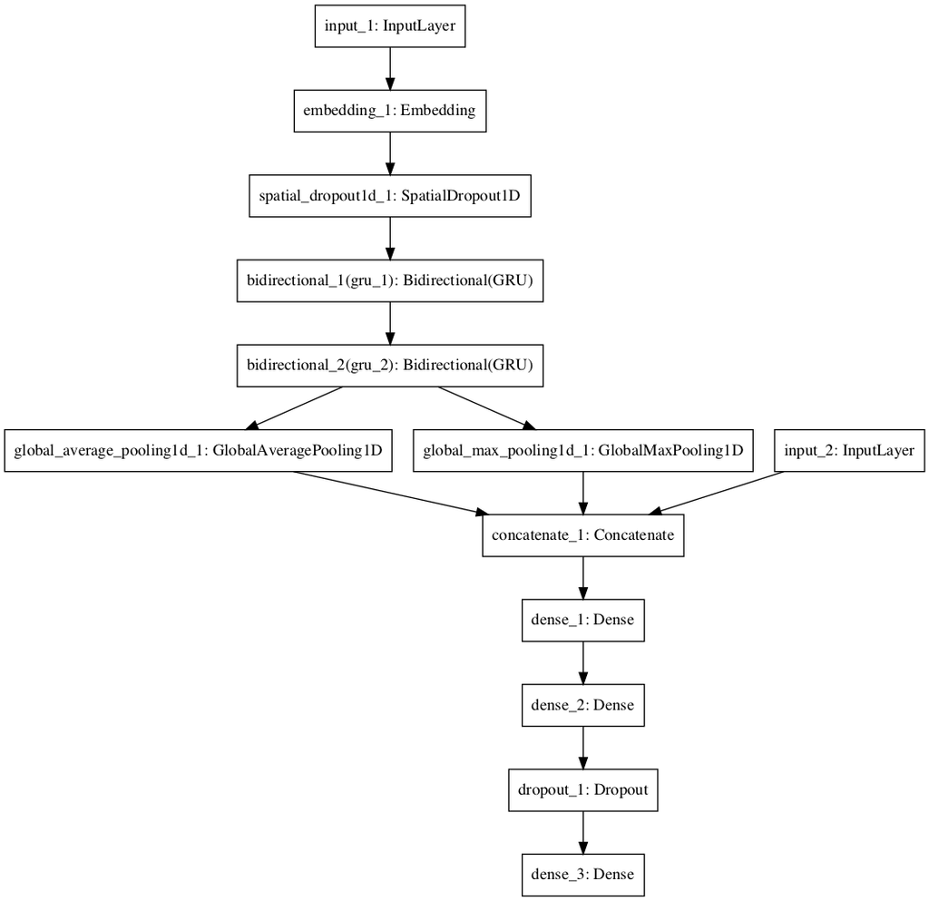

```python
from keras.utils import plot_model
plot_model(model, to_file='model_arch.png')
```

```python
checkpoint_predictions = []
weights = []
use_meta_feat= True
for model_idx in range(NUM_MODELS):
    model = build_model(embedding_matrix, use_meta_feat)
    for global_epoch in range(EPOCHS):
        if(use_meta_feat==False):
            history= model.fit(train_text_X, train_y, batch_size=BATCH_SIZE, epochs=1, verbose=0, validation_data=(val_text_X, val_y),callbacks=[LearningRateScheduler(lambda _: 1e-3 * (0.6 ** global_epoch))])
            checkpoint_predictions.append(model.predict(val_text_X, batch_size=2048)[0].flatten())
        else:
            history= model.fit([train_text_X,train_meta_X], train_y, batch_size=BATCH_SIZE, epochs=1, verbose=0, validation_data=([val_text_X, val_meta_X], val_y),callbacks=[LearningRateScheduler(lambda _: 1e-3 * (0.6 ** global_epoch))])
            checkpoint_predictions.append(model.predict([val_text_X, val_meta_X], batch_size=2048)[0].flatten())
        weights.append(2 ** global_epoch)

predictions = np.average(checkpoint_predictions, weights=weights, axis=0)
```

```python
# save model and architecture to single file
model.save("Model/model_meta_feat.h5")
# print("Saved model to disk")
```

```python
# load saved model and architecture
from keras.models import load_model
model = load_model('Model/model_meta_feat.h5')
```

```python
if(use_meta_feat==True):
    y_test = model.predict([test_text_X, test_meta_X], batch_size=1024, verbose=1)
else:
    y_test = model.predict(test_text_X, batch_size=1024, verbose=1)
sample_submission = pd.read_csv(f'Dataset/jigsaw-toxic-comment-classification-challenge/sample_submission.csv')
sample_submission[TARGET_COLS] = y_test
sample_submission.to_csv(f'Output/submission_meta_feat.csv', index=False)
```

A few prediction examples have been shown below on test data:

[figure not shown]

This qualitative analysis reveals that the model is able to fairly confidently identify many different forms of toxicity, most notably:

1. Very obvious straightforward comments are detected with very high confidence and tagged accordingly.
2. Racial/identity slurs are also detected with very high confidence and labelled as identity hate.
3. Model is also able to fairly identify immature insults, as shown by model's ability to label **"Your face"** as Toxic and Insult.
4. Neutral statements are labelled as Non-toxic as shown in the first row.
5. Model is also able to identify fairly complex sentence structure.